# **Méthodologie en Génétique Humaine**

## **TP: Étude d'association pan-génomique dans le diabète de type 1**

### Activité préparatoire

*Claire Vandiedonck*

Déroulé de l'ensemble du TP : *cette activité préparatoire porte sur les parties 0 à 2 (en bleu)*

> 0. Synopsis  
> 1. Première partie: Evaluation de la faisabilité de l'étude

> 1.A. Identification des régions déjà connues pour leur association au DT1 de manière significative  
> 1.B. Calcul de puissance pour retrouver les mêmes régions ou d’autres variants avec effets similaires dans une nouvelle cohorte

> 2. Deuxième partie: Formatage de fichiers de génétique et découverte du logiciel PLINK  
> 3. Troisième partie: Statistiques descriptives et QC  
> 4. Quatrième partie: Analyse d'association génétique cas-contrôles  
> 5. Cinquième partie: Analyse d'association familiale

## Avant d'aller plus loin

**Attention:** Ne travaillez pas directement sur ce notebook pour ne pas le perdre. Dupliquez-le et renommez-le par exemple en ajoutant vos initiales et travaillez sur cette nouvelle copie. Pour ce faire, dans le panneau de gauche, faites un clic droit sur le fichier et sélectionnez "Duplicate". Puis, toujours dans la colonne de gauche, faites un clic droit sur cette copie et sélectionnez "rename" pour changer le nom. Ouvrez ensuite cette nouvelle version en double cliquant dessus. Vous êtes prêt(e) à démarrer!  
**N'oubliez pas de sauvegarder régulièrement votre notebook**: `Ctrl` + `S`. ou en cliquant sur l'icone 💾 en haut à gauche de votre notebook ou dans le Menu du JupyterLab "File puis "Save Notebook"!

**Rappel :** Vous pouvez prendre des notes directement dans ce notebook, en ajoutant une cellule Markdown en cliquant sur l'icône `➕` dans la barre des menus, et en choisissant son format dans le menu déroulant. Les astuces pour utiliser les cellules des notebooks sont rappelées tout en bas dans un cadre bleu ⏬.

Dans ce TP, vous lancerez chaque cellule l'une après l'autre dans l'ordre. Si vous revenez en arrière et rééxécuter une cellule, veillez à relancer les suivantes. Les cellules sont numérotées dans leur ordre d'éxécution.

*=> A propos de ce jupyter notebook*

Pour ce TP, nous aurons besoin d'éxécuter du code **bash** et **R**. Nous allons utiliser un notebook avec un noyau **python** et indiquer que les cellules doivent être éxécutées en bash (natif) en ajoutant `%%bash` au début de chaque cellule, et en ajoutant `%%R` au début de chaque cellule `R` après avoir installé et chargé `Rpy2` au début du notebook. Cela restera très lisible.

Avant de commencer, nous devons donc charger le module `Rpy2` avec la commande suivante.

```python
#cell 1
%load_ext rpy2.ipython
```

Vous pouvez éxécuter cette commande python pour connaître votre répertoire de travail puis lister ce qu'il contient.

```python
# cell 2
import os
os.getcwd()
```

```
'/srv/home/cvandiedonck/meg_m1_ghm_gwas'
```

**Le résultat devrait ressembler à :**"/srv/home/mylogin/meg_m1_ghm_gwas" avec votre login. Si ce n'est pas le cas, changez de répertoire avec la commande "os.chdir('path')" ou applez votre enseignant à l'aide!

Pour lister ce qu'il contient, vous pouvez tenter avec les 3 langages:

- en python: la commande affichera aussi les fichiers cachés commençant par un `.`.

```python
# cell 3
os.listdir()
```

```
['.jupyter',
 '.conda',
 'MR',
 'output',
 '.gitignore',
 'T1D_GWAS_session1.html',
 'ng.3245.pdf',
 'T1D_GWAS_session1_correction_partielle.ipynb',
 '.git',
 '.local',
 'plink.fam',
 'T1D_GWAS_session2.ipynb',
 '.yarn',
 'T1D_GWAS_activité_préparatoire.ipynb',
 '.ipython',
 '.profile',
 'T1D_GWAS_activité_préparatoire-correction.ipynb',
 '.bashrc',
 'input',
 '.bash_logout',
 'T1D_GWAS_session1.ipynb',
 '.ipynb_checkpoints',
 'plink.log',
 'T1D_GWAS_PIRG2.correction.ipynb',
 'archive',
 'T1D_GWAS_session3_correction.ipynb',
 'T1D_GWAS_session1_correction.ipynb',
 'T1D_GWAS_session3.ipynb',
 'untitled.md',
 'README.md',
 'binder',
 '.npm']
```

- en bash:

```python
%%bash
# cell 4
ls
```

```
archive
binder
input
MR
ng.3245.pdf
output
plink.fam
plink.log
README.md
T1D_GWAS_activité_préparatoire-correction.ipynb
T1D_GWAS_activité_préparatoire.ipynb
T1D_GWAS_PIRG2.correction.ipynb
T1D_GWAS_session1_correction.ipynb
T1D_GWAS_session1_correction_partielle.ipynb
T1D_GWAS_session1.html
T1D_GWAS_session1.ipynb
T1D_GWAS_session2.ipynb
T1D_GWAS_session3_correction.ipynb
T1D_GWAS_session3.ipynb
untitled.md
```

- en R:

```python
%%R
# cell 5
list.files()
```

```
 [1] "archive"
 [2] "binder"
 [3] "input"
 [4] "MR"
 [5] "ng.3245.pdf"
 [6] "output"
 [7] "plink.fam"
 [8] "plink.log"
 [9] "README.md"
[10] "T1D_GWAS_activité_préparatoire-correction.ipynb"
[11] "T1D_GWAS_activité_préparatoire.ipynb"
[12] "T1D_GWAS_PIRG2.correction.ipynb"
[13] "T1D_GWAS_session1_correction_partielle.ipynb"
[14] "T1D_GWAS_session1_correction.ipynb"
[15] "T1D_GWAS_session1.html"
[16] "T1D_GWAS_session1.ipynb"
[17] "T1D_GWAS_session2.ipynb"
[18] "T1D_GWAS_session3_correction.ipynb"
[19] "T1D_GWAS_session3.ipynb"
[20] "untitled.md"
```

## **0 - Synopsis**

### Objectifs du TP

Dans ce TP, vous allez réaliser une étude d’association génétique dans le diabète de type 1 (DT1) dans une cohorte française au moyen d’outils informatiques et statistiques (Marees AT et al., 2018). Les sujets d'étude proviennent d'une série de patients atteints de diabète de type 1 et de contrôles sains. Tous les échantillons ont été génotypés au moyen de la puce Illumina immunochip (Trynka et al., 2011, Parkes M. et al., 2013). Au cours de ce TP, vous serez amenés à:

- évaluer la la puissance de l'étude
- comprendre le format des fichiers de génotypage pour les logiciels d'analyse génétique
- effectuer des contrôles de qualité
- nettoyer/filtrer les données
- réaliser l'étude d'association pangénomique de type cas/contrôles et de type familial
- interpréter vos résultats en comparaison avec les articles publiés par le Type 1 Diabetes Genetics Consortium (Onengut-Gumuscu S, et al., 2015, Robertson CC et al., 2021).

⚠️ Vous aurez 2 notebooks: un pour l'activité préparatoire (celui-ci) et un pendant la séance de TP

### Références

1. Trynka G, et al. Dense genotyping identifies and localizes multiple common and rare variant association signals in celiac disease. Nature Genetics 43, 1193–1201 (2011) doi.org/10.1038/ng.998
2. Parkes M, et al. Genetic insight into common pathways and complex relationships among immune-mediated diseases. Nature Genetics 14, 661-673 (2013) doi.org/10.1038/nrg3502
3. Marees AT et al. A tutorial on conducting genome‐wide association studies: Quality control and statistical analysis. Int J Methods Psychiatr Res. 27:e1608. (2018) doi.org/10.1002/mpr.1608
4. Onengut-Gumuscu S et al. Fine mapping of type 1 diabetes susceptibility loci and evidence for colocalization of causal variants with lymphoid gene enhancers. Nature Genetics 47, 381–386 (2015) doi.org/10.1038/ng.3245
5. Robertson CC et al. (2021). Fine-mapping, trans-ancestral and genomic analyses identify causal variants, cells, genes and drug targets for type 1 diabetes. Nature Genetics 53, 962–971 (2021). doi.org/10.1038/s41588-021-00880-5

## **I - Première partie: évaluation de la faisabilité de l'étude**

Avant d'entamer toute étude de génétique, il est nécessaire d'évaluer l'état des connaissances et de vérifier si l'étude prévue aura la puissance nécessaire pour identifier des associations génétiques.

### **1.A. Quelles sont les régions génétiques déjà associées au DT1 ?**

Pour répondre à cette question, vous allez étudier le résultats publiés par par Onengut-Gumuscu et al. Nature Genetics (2015), présentant les derniers résultats de GWAS publiés par le consortium international de l'étude du diabète de type 1 (T1DGC for Type 1 Diabetes genetics Consortium). L'article au format .pdf est présent sur moodle et dans votre environnement jupyterlab.

**Q1.1.** *Combien de **régions génomiques** avaient été impliquées dans le diabète de type I (DT1) avant le démarrage de l'étude ?*

41 régions étaient connues avant le design de l'immunochip en février 2000

**Q1.2.** *Dans quels buts a été conçue l'**Immunochip** ? Quelle a été la stratégie de conception de l'Immunochip ?*

*votre réponse...* 4 buts indiqués dans l'article:

i. identifier de nouveaux facteurs génétiques de risque du DT1

ii. faire une cartographie fine des régions associées pour identifier les SNPs candidats pour un rôle causal les plus crédibles

iii. analyser ces SNPs candidats au regard des séquences régulatrices (c'est un but indirect, plutôt une conséquence du ii)

iv. combiner les résultats de GWAS de plusieurs maladies autoimmunes

Pour info les 20 maladies étudiées sont: spondylathrite ankylosante (SA), les thyroïdtes autoimmunes (ATD), la maladie coeliaque (CEL), la maladie de Crohn (CRO), l'arthrite juvenile idiopathique (JIA), la sclérose en plaques (MS), la cirrhose biliaire primitive (PBC), le psoriasis (PSO), la polyarthrite rhumatoïde (RA), le lupus systémique érythémateux (SLE), le diabète de type 1 (T1D), la rectocolite hémorragique (UC), l'alopécie areata, les maladies inflammatoires chroniques de l'intestin (IBD), la sensibilité allergique et réponse aux IgE, la narcolepsie, la cholangite sclérosante primitive, le syndrome de Sjögren, la sclérodermie systémique et le vitiligo.

**Q1.3.** *Quelle est la **structure des échantillons**? Combien de cas et de contrôles ont été étudiés après QC (Quality Controls sur les SNPs et sur les sujets) ? Quelle est leur origine géographique?*

*votre réponse...* Des données Cas/Contrôles et d'autres familiales.

- Après QC sur les SNPs (test principal):  
6670 patients + 12264 controles (=6523 contrôles de la cohorte 1958 + 2893 contrôles du UK National Blood Service et 2848 contrôles du NIHR Cambridge Biomedical Research Centre Cambridge Ressources)  
+ 2601 paires de germains du T1DGC de 5 régions (pour info, non mis dans le papier: Amérique du Nord, Asie-Pacifique, UK, Sardaigne, danemark) -> donc 2601 cas et 2601 contrôles  
+ 69 trios du T1DGC de 5 régions -> donc 69 patients et 138 contrôles!

- Après QC sur SNPs et sujets (bas colonne gauche page dans online methods du papier): 10 796 individus: 6683 cas, 12 173 controls, 2601 ASP et 69 trios

[Selon immunobase, il y avait 6670 cas, 9416 controls et 2601 familles.]

**Q1.4.** *Combien de **SNPs** ont passé les seuils de QC ?*

*votre réponse...*

138, 229 SNPs dans le corps du texte mais 135,870 dans les méthodes...

**Q1.5.** *Avec R, calculer la valeur de **seuil de Bonferroni pour le nombre de SNPs ayant passé les QCs**. S'agit-il du seuil utilisé dans l'artcile?*

```python
%%R
#cell 6 et votre code R
print(0.05/138229) # avce le nb de SNPs après QCs
print(0.05/154939) # avec le nb de SNPs avant QC, utilisé pour le seuil choisi dans le papier
```

```
[1] 3.617186e-07
[1] 3.227076e-07
```

*votre réponse...*

Normalement cela devrait être p<5E-08 afin de prendre en compte la correction multiples. Mais ici ils ont pris un seuil moins stringent de 3.23x10-7

**Q1.6.** *En dehors du CMH qui n'est pas étudié dans cet article, **combien de régions ont été trouvées associées** à leur seuil? En bas de la colonne 2 de la 1ère page de l'article, combien de régions les auteurs répliquent-ils et combien de nouvelles régions sont associées au seuil 5e-8 ?*

*votre réponse...*

Ils répliquent 38 associations déjà connues (voir article bas colonne de droite page 1) et ils en identifient 4 nouvelles au seuil 5e-8 = 42 et ils identifient 2 suggestives < 1e-7 = 44 en tout

**Q1.7.** *Quelle **version de la séquence de référence** du génome est utilisée dans cet article?*

*votre réponse...*

génome hg19 = GRch37 à trouver dans les méthodes dans la section SNP annotation

### **I.B. Quelle est la puissance de détecter les mêmes associations ou de nouvelles associations avec des effets comparables ?**

Dans cette partie, vous allez évaluer la capacité de répliquer les effets déjà publiés dans une cohorte française génotypée au moyen de l'immunochip. Vous réaliserez le GWAS de cette cohorte dans les prochaines séances de TP.

Pour rappel, dans un test d'association génétique:

- `l'hypothèse nulle (H0)` correspond à l'absence d'association, c'est à dire qu'il n'y a pas d'effet: les fréquences alléliques sont identiques entre cas et contrôles.
- `l'hypothèse alternative (H1)` est celle de l'absence d'égalité des fréquences alléliques: il existe un effet, c'est à dire une association allélique.

En statistiques, on définit la `puissance` comme la probabilité de detecter un effet s'il existe. Il s'agit de la probabilité de rejeter H0 sachant que H0 n'est pas vraie. Il faut connaitre une hypothèse H1 spécifique, c'est-à-dire connaitre l'amplitude de l'effet en question. Dans une étude d'association génétique, l'OR correspond à l'effet.

Dans le cas d'un test de comparaison de fréquences, il faut également connaître la fréquence de chaque groupe, cas et contrôles sous H1. Connaissant la fréquence de contrôles et l'OR, vous pouvez déduire la fréquence des cas en admettant des effectifs de taille similaire entre cas et contrôles (voir formule plus bas).

Si vous ne génotypez pas directement le SNP reporté comme étant associé, mais un SNP en déséquilibre de liaison (DL) avec lui, certains outils de calcul de puissance vous demandent de renseigner ce DL. Dans ce TP, nous espérons que le variant associé est bien inclus dans l'immunochip. Nous supposerons donc que nous testons directement le variant associé pour les calculs de puissance.

- la région du gène de l'Insuline (*INS*) en 11p15.5: chr11:2092701-2260001
- le gène *PTPN22* en 1p13.2: chr1:113288123-114009223
- **collecte des informations des 3 meilleures régions associées avant calcul de puissance:**

Pour calculer la puissance, vous devez collecter des informations concernant les régions déjà associées.

A titre de référence et pour comparaison, nous vous fournissons les valeurs pour la région du CMH (en 6p21.3 : chr6:32350867-32714887) et les résultats du calcul de puissance dans les tableaux 1 et 2 ci-dessous que vous complèterez. Vous pouvez aussi retrouver les tableaux sur le document google partagé à ce lien: https://docs.google.com/spreadsheets/d/1M6C4cbVxKXgWMUIWA10pisS6AXS4RJHzZRUBlP2gij0/edit?usp=sharing.

**Tableau 1.** Valeurs de référence pour les top SNPs des 3 meilleurs régions associées au DT1

| **région** | **SNP** | **allèles** | **p-value** | **OR pour mineur** | **OR pour majeur** | **MAF** | **freq majeur** | **freq allèle mineur patients** | **freq allèle majeur patients** |
| --- | --- | --- | --- | --- | --- | --- | --- | --- | --- |
| CMH | rs6916742 | C>T | <e-100 | 0.24 | 4.17 =1/0.24 | 0.39 | 0.61 | 0.13 =0.39*0.24(1-0.39+0.39*0.24) | 0.87 |
| INS |  |  |  |  |  |  |  |  |  |
| PTPN22 |  |  |  |  |  |  |  |  |  |

**Q1.8.** *Pour les deux régions, complétez les colonnes du Tableau 1 à partir des valeurs de l'article Onengut-Gumuscu et al. 2015 :*

le top SNP (celui qui a la p-value la plus faible) et ses allèles Majeur>Mineur

la p-value de l'association au DT1

l'OR de risque correspondant

la fréquence de l'allèle de risque chez les contrôles de l'étude

*Entrez ici d'éventuelles explications pour compléter le tableau...*

*- Pour le Le CMH (en 6p21.3):* top SNP = rs6916742 avec un p = 4.00E-307 (Référence Bradfield et al. Plos Genet 2011 ( https://doi-org.proxy.insermbiblio.inist.fr/10.1371/journal.pgen.1002293; qui pourtant réfère au papier du WTCCC sans ce SNP!; j'ai préféré prendre un seul SNP que ceux taggant DR3 et DR4 non référencés dans OpenTargets ni le GWAS catalogue -> voir papier de Hu X. 2015 nature genet dans la supp Table 2 pour détail des SNPs, ou Erlich et al. 2008 Diabetes pour DR3 et DR4 ou Johnson MB 2019 10.1007/s11892-019-1141-6).

OR = OR=0.24 pour l'allèle T = mineur = protecteur <=> OR = 1/0.24=4.17 pour l'allèle C de risque La MAF n'est pas connue -> dbSNP: MAF =fre(T)= 0.39 pour T, donc freq(C)= 0.61

*- Pour l'insuline (attention, prendre la 1ère ligne, la seconde étant une association indépendantre du lead SNP)* top SNP = rs689 ave une pvalue de <1E-100 (note: il y avait une autre référence dans T1DBase associée à 1E-195) OR = 0.42 pour l'allèle mineur A selon l'étude, soit un OR de risque 2.38 pour l'allèle majeur T MAF = 0.30 dans l'étude (qui regarde l'autre brin que 1KG !!!) <=> donc fréquence de l'allèle de risque (T)= 0.7*

*- Pour PTPN22 (déjà vu précédemment dans le TP!)* top SNP = rs2476601 avec p=1.1e-122 (ils indiquent <1e-100) OR=1.89 pour l'allèle mineur A de risque MAF=0.09*

| **région** | **SNP** | **allèles** | **p-value** | **OR pour mineur** | **OR pour majeur** | **MAF** | **freq majeur** | **freq allèle mineur patients** | **freq allèle majeur patients** |
| --- | --- | --- | --- | --- | --- | --- | --- | --- | --- |
| CMH | rs6916742 | C>T | <e-100 | 0.24 | 4.17 =1/0.24 | 0.39 | 0.61 | 0.13 =0.39x0.24(1-0.39+0.39x0.24) | 0.87 |
| INS | rs689 | T>A | <e-100 | 0.42 | 2.38 =1/0.42 | 0.30 | 0.70 | 0.15 =(0.3x0.42)/(1-0.3+(0.3x0.42)) | 0.85 |
| PTPN22 | rs2476601 | G>A | <e-100 | 1.89 | 0.53 =1/1.89 | 0.09 | 0.91 | 0.16 =(0.09x1.89)/(1-0.09+0.09x1.89) | 0.84 |

- **Calcul de puissance pour les 3 meilleures régions associées:**

A présent vous pouvez calculer la puissance de détecter ces mêmes effets ou des effets d'amplitude similaire, connaissant la fréquence de l'allèle de risque associé et l'OR.

Il existe plusieurs outils permettant de calculer la puissance dans le cas d'un test d'association génétique, tels que:  
- Genetic Power Calculator : http://zzz.bwh.harvard.edu/gpc/  
- Quanto : http://biostats.usc.edu/Quanto.html  
- GAS Power Calculator: https://csg.sph.umich.edu/abecasis/gas_power_calculator/index.html

Leur utilisation n'est pas si simple car elle ne prend pas en compte les 3 seuls paramètres: OR, fréquence et taille pour déterminer la puissance. Ils prennent également en paramètre d'entrée la prévalence de la maladie (afin de déduire le nombre de contrôles en réalité atteints). Ils peuvent considérer si le SNP testé est le variant causal ou s'il est en DL avec le causal. Il faut alors renseigner soir le DL soit les fréquences génotypiques ou alléliques au SNP testé en plus du causal. Ces outils peuvent aussi prendre en compte différents modèles (additif, dominant, etc...) voire des effets de l'environnement et des interactions. De plus, ils ne prennent pas directement en compte l'OR mais d'autres valeurs d'effet comme le risque relatif par génotype.

Dans ce TP, nous avons décidé d'utiliser un **pw, un paquet de R dédié au calcul de puissance pour les tests statistiques classiques** (http://cran.r-project.org/web/packages/pwr/index.html). Ce paquet présente un double avantage: (i) il est générique donc utilisable en dehors d'un contexte génétique; (ii) il permet de générer une courbe de la puissance en fonction de la taille d'échantillon en une commande.

Chargeons le paquet pwr avec la commande suivante:

```python
%%R
# cell 7
library(pwr)
```

Nous l'utiliserons dans le contexte d'un **test statistique du Chi2 à 1 degré de liberté** que nous pouvons utiliser pour un test allélique. La fonction est `pwr.chisq.test()`. Les arguments que nous devons renseigner sont:

- `N`: la taille totale des échantillons
- `sig.level` : le degré de signification (vous utiliserez le seuil de p-value corrigé pour un GWAS, c'est-à-dire 5x10-8)
- `w`: l'effect size selon la définition de Cohen.

L'`effect size` peut se mesure de différentes façons dans un test statistique. En génétique, on choisit plutôt l'OR que la différence entre les fréquences alléliques théoriques chez les cas et contrôles. Plus classiquement, cette mesure de l'amplitude de l'effet peut être mesurée par la valeur `d` de Cohen. C'est celle qui est implémentée dans ce paquet. Il n'est pas nécessaire de rentrer dans le détail de cette mesure mais vous pouvez trouver au lien suivant un outil en ligne pour obtenir les conversions d'un OR en valuer d de Cohen ou tout autre mesure de la taille de l'effet: https://www.escal.site/

Nous calculerons l'effect size `d` directement dans R au moyen de la formule le reliant à l'OR:

> d <- sqrt(3)*ln(OR)/pi

Voici ci-dessous les commandes pour calculer la puissance pour la région du CMH à partir d'une taille d'échantillon de 100 et pour générer la courbe puissance ~ taille de l'échantillon:

```
[1] 0.7872514

     Chi squared power calculation

              w = 0.7872514
              N = 100
             df = 1
      sig.level = 5e-08
          power = 0.9922654

NOTE: N is the number of observations
```

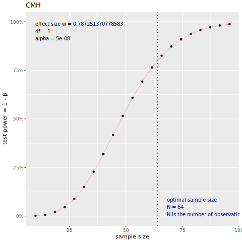

```python
%%R
# cell 8
d_cmh <- sqrt(3)*log(4.17)/pi
print(d_cmh)
print(pwr.chisq.test(w = d_cmh, df = 1, N = 100, sig.level = 5e-8))

plot(pwr.chisq.test(w = d_cmh, df = 1, power = 0.80, sig.level = 5e-8), main="CMH")
```

**Q1.9.** *Pour le CMH et les deux régions des gènes de l'INS et PTPN22, complétez les colonnes du Tableau 2 à partir des valeurs de l'article Onengut-Gumuscu et al. 2015 et tracez la courbe puissance ~ taille échantillon.*

**Tableau 2.** Puissance pour les différents effectifs

| **région** | **50** | **100** | **200** | **300** | **500** |
| --- | --- | --- | --- | --- | --- |
| CMH | 55% | 99% | 100% | 100% | 100% |
| INS |  |  |  |  |  |
| PTPN22 |  |  |  |  |  |

*solution*

| **région** | **50** | **100** | **200** | **300** | **500** |  |
| --- | --- | --- | --- | --- | --- | --- |
| CMH | 55% | 99% | 100% | 100% | 100% | 100% |
| INS | 1.92% | 25.12% | 90.48% | 99.77% | 100% |  |
| PTPN22 | 0.14% | 2.61% | 31.28% | 73.49% | 99.17% |  |

```python
%%R
#cell 9 pour les calculs
cat("CMH")
for (i in c(50,100,200,300,500)){
   print(i)
    print(pwr.chisq.test(w=d_cmh,df=1, N=i, sig.level=5e-8))
}

cat("INS")
d_ins <- sqrt(3)*log(2.38)/pi
print(d_ins)

for (i in c(50,100,200,300,500)){
   print(i)
    print(pwr.chisq.test(w=d_ins,df=1, N=i, sig.level=5e-8))
}

cat("PTPN22")
d_ptpn22 <- sqrt(3)*log(1.89)/pi
print(d_ptpn22)

for (i in c(50,100,200,300,500)){
   print(i)
    print(pwr.chisq.test(w=d_ptpn22,df=1, N=i, sig.level=5e-8))
}
```

```
CMH[1] 50

     Chi squared power calculation

              w = 0.7872514
              N = 50
             df = 1
      sig.level = 5e-08
          power = 0.5459349

NOTE: N is the number of observations

[1] 100

     Chi squared power calculation

              w = 0.7872514
              N = 100
             df = 1
      sig.level = 5e-08
          power = 0.9922654

NOTE: N is the number of observations

[1] 200

     Chi squared power calculation

              w = 0.7872514
              N = 200
             df = 1
      sig.level = 5e-08
          power = 1

NOTE: N is the number of observations

[1] 300

     Chi squared power calculation

```

[output cut: 126 more lines]

```
          power = 0.7348508

NOTE: N is the number of observations

[1] 500

     Chi squared power calculation

              w = 0.3509632
              N = 500
             df = 1
      sig.level = 5e-08
          power = 0.991723

NOTE: N is the number of observations
```

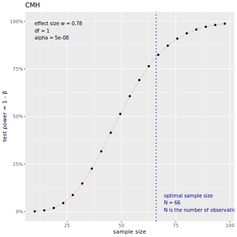

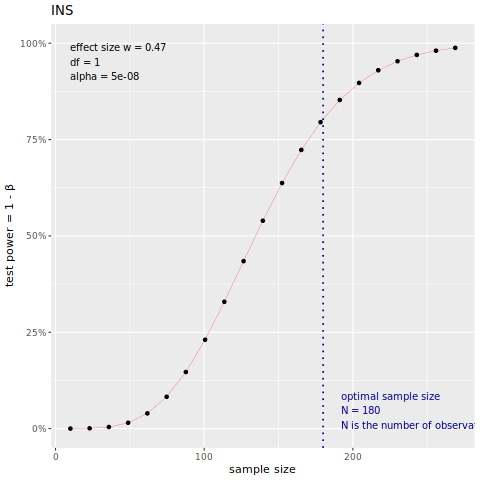

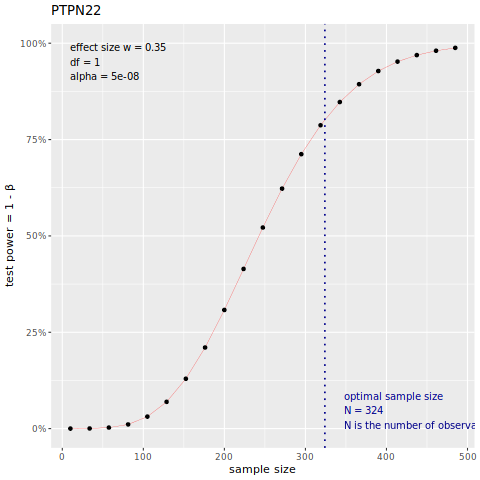

```python
%%R
# cell 10, votre code R pour les figures
print(plot(pwr.chisq.test(w=0.78, df=1, power = 0.80,sig.level=5e-8), main="CMH"))
print(plot(pwr.chisq.test(w=0.47,df=1, power = 0.80,sig.level=5e-8), main="INS"))
print(plot(pwr.chisq.test(w=0.35, df=1, power = 0.80,sig.level=5e-8), main="PTPN22"))
```

**Q1.10.** *Commentez les résultats.*

**En pratique**  
⚠️ On calcule la puissance avant tout projet afin de connaitre la taille des échantillons recquise pour mettre en évidence un effet minimum. Cependant, on recalcule la puissance à la fin de l'étude en fonction des fréquences alléliques effectivement estimées dans notre échantillon afin de s'assurer, en cas d'absence d'association, qu'on avait bien la puissance nécessaire. Pensez-y pour votre compte-rendu!

**=> Bravo!**

Vous êtes désormais prêts pour mener le GWAS "cas-contrôles". mais nous devons encore apprendre à utiliser le logiciel PLINK pour mener cette étude.

## **II. Deuxième partie: format de fichiers de génétique et découverte du logiciel PLINK**

### **II.A. Le logiciel PLINK**

Pour réaliser l'étude d'association, vous devrez préparer les fichiers sous un format utilisable par les logiciels de génétique. Le principal logiciel que vous utiliserez est **PLINK**: https://www.cog-genomics.org/plink/1.9/.

En plus de permettre des analyses d'association, ce logiciel permet de manier les fichiers de génétique, de faire des sélections et filtrages, et de réaliser certains contrôles de qualité. Il est mondialement reconnu comme un des meilleurs outils pour réaliser des GWASs. Ce logiciel libre existe en versions windows, mac et unix. Le tutoriel (https://www.cog-genomics.org/plink/2.0/tutorials/tutorial_setup) est très détaillé et donne de nombreux exemples.

Ce logiciel a été développé par Shaun Purcell. Il avait alors une double affiliation au Center for Human Genetic Research (CHGR), Massachusetts General Hospital (MGH) et au Broad Institute of Harvard & MIT. Il est désormais chef de son labo (https://zzz.nyspi.org/). La version originale présente sur son site web était la version v1.07 (10-Oct-2009).

Il existe à présent une nouvelle version beta **PLINK 1.9** dont l'objectif est principalement d'améliorer la vitesse et la fonctionnalité pour de très gros jeux de données. Elle a été principalement développée par par Christopher Chang at Human Longevity, Inc., par Carson Chow and Shashaank Vattikuti at the NIH-NIDDK's Laboratory of Biological Modeling, Laurent Tellier at the BGI Cognitive Genomics Lab, and James Lee at the University of Minnesota, with additional funding from the Purcell Lab at Mount Sinai School of Medicine du BGI Cognitive Genomics Lab!

**En pratique**  
PLINK s'utilise en lignes de commandes « relativement simples ». Toutes les informations pour spécifier les fichiers d'entrée (« input »), les fichiers de sortie (« output ») et les paramètres d'utilisation sont détaillés dans le menu à gauche de la page d’accueil de PLINK.

### **II.B. Lancement de PLINK**

Pour faire tourner PLINK sous Unix ou dans ce notebook, vous appelez d'abord le programme en tapant : `plink` dans une cellule **bash**.

*N'ayez pas peur de la boite rouge qui apparait. Cet affichage disparaitra quand les commandes seront complètes.*

```python
%%bash
## cell 11
plink
```

```
PLINK v1.90b6.12 64-bit (28 Oct 2019)          www.cog-genomics.org/plink/1.9/
(C) 2005-2019 Shaun Purcell, Christopher Chang   GNU General Public License v3

  plink <input flag(s)...> [command flag(s)...] [other flag(s)...]
  plink --help [flag name(s)...]

Commands include --make-bed, --recode, --flip-scan, --merge-list,
--write-snplist, --list-duplicate-vars, --freqx, --missing, --test-mishap,
--hardy, --mendel, --ibc, --impute-sex, --indep-pairphase, --r2, --show-tags,
--blocks, --distance, --genome, --homozyg, --make-rel, --make-grm-gz,
--rel-cutoff, --cluster, --pca, --neighbour, --ibs-test, --regress-distance,
--model, --bd, --gxe, --logistic, --dosage, --lasso, --test-missing,
--make-perm-pheno, --tdt, --qfam, --annotate, --clump, --gene-report,
--meta-analysis, --epistasis, --fast-epistasis, and --score.

"plink --help | more" describes all functions (warning: long).
```

[output not shown]

Le programme démarre et s'arrête avec une erreur car vous n'avez pas encore donné de fichiers d'entrée (*inputs*).

> - Si toutefois vous vouliez utiliser PLINK en dehors d'adenine, voici des conseils d'utilisation **sous Windows**:

> Vous devez utiliser le DOS en utilisant l'invite de commande (cmd.exe) ou, sur les dernières versions de windows, le "windows power shell" à partir du menu "fichier" de votre répertoire de travail. Vos fichiers "inputs" doivent être placés dans le même répertoire (=dossier) que l'éxécutable de PLINK plink.exe. Trois options s'offrent à vous, de la plus compliquée à la plus simple!:

> ```
> **(1)** Dans le menu « Démarrer » de Windows, rechercher « cmd » puis indiquez le chemin du répertoire où est situé plink.exe (pour changer de répertoire, la commande est “cd”; pour passer au répertoire supérieur, taper “cd ..” ; vous pouvez utiliser la flèche de tabulation à gauche du clavier pour autocompléter les noms de dossiers)
>
> **(2)** Alternativement, trouvez le fichier cmd.exe (en général dans Windows\system 32; vous pouvez le trouver aussi dans les accessoires). Faire une copie que vous placez dans le dossier contenant plink.exe. Si vous double-cliquez alors sur cmd.exe dans ce répertoire, vous pouvez utiliser PLINK.
>
> **(3)** Encore plus simplement, vous pouvez aussi créer en local un répertoire dans lequel vous mettrez tous vos documents du TP (fichiers d'input, d'output) ainsi que vos programmes. Copiez et collez l'executable plink.exe dans ce répertoire. Copiez et collez également l'exécutable de l'invite de commande cmd.exe dans ce répertoire. Si vous double-cliquez alors sur cmd.exe dans ce répertoire, vous pouvez utiliser PLINK.
>
>  Alternativement, si vous travaillez depuis windows power shell, il faut spécifier que plink est dans le répertoire de travail en tapant: .\plink
> ```

### **II.C. Fichiers d'entrée**

Commençons par nous familiariser avec l'utilisation avec des fichiers « test ».

PLINK a besoin de deux types de fichiers d'entrée.

- `.ped` pour le fichier de structure de pedigree
- `.map` pour le fichier des marqueurs génotypés

Dans le répertoire `input` de votre environnement jupyterlab, vous avez des fichiers d'entrée d'exemple avec le préfixe `test.`. Les fichiers sont aussi disponibles sur moodle.

##### **1. Exploration des fichiers d'entrée en dehors de PLINK**

Ouvrez-les en double cliquant dessus dans le jupyterlab (ou avec un éditeur de texte comme notepad++ sous windows ou gedit sous unix si vous ne travaillez pas sur adénine). **Sans lancer PLINK**, cherchez des explications sur leur structure dans la documentation de PLINK à ce lien en bas du menu de gauche"https://www.cog-genomics.org/plink/1.9/formats). Ne vous arrêtez pas en haut de la page! Allez sur les paties dédiées aux ficg=hiers .bed et .map.

**Q2.1** *Concernant le fichier de structure de **pedigree**:*

*- Combien de sujets ont été génotypés ?*

*votre réponse*

8

*- Sont-ils apparentés ? Ont-ils les mêmes parents ? Quelles colonnes vous donnent ces informations ?*

*votre réponse*

A priori, 5 d'entre eux, c'est à dire le 1er, 5ème, 6ème, 7ème et 8ème ne sont pas apparentés car ils ont tous un n° de pedigree différent d'après la 1ère colonne. Le père et la mère de ces sujets (colonnes 3 et 4) sont notés 0, mais il ne s'agit pas des mêmes parents : le 0 ici indique que le parent n'est pas connu Pour les 2ème, 3ème et 4ème sujets, ils sont de même pedigree n°2. Le 4ème sujet a pour père le 2ème et pour mère le 3ème sujet.

*- Quel est l'identifiant du 5ème sujet ? Est-il possible de le distinguer des autres sujets en considérant un identifiant unique ?*

*votre réponse*

L'identifiant du 5ème sujet est 1 donné par la deuxième colonne. En combinant cet identifiant à celui du pedigree (1ère colonne), on génère un identifiant unique : 3_1 pour le 5ème sujet.

*- Quel est le sexe des sujets ? Quelle colonne vous donne cette information ? Est-ce cohérent avec les autres colonnes ?*

*votre réponse*

Ce sont tous des sujets masculins d'après la 5ème colonne sauf le 3ème qui est une femme et qui est en effet la mère du 4ème sujet.

*- Connaît-on leur statut vis-à-vis de la maladie ? Combien y a-t-il de cas et de contrôles ?*

*votre réponse*

D'après la colonne 6, il y a 3 cas codés 2, 3 contrôles codés 1, et 2 sujets de statut inconnu noté 0 pour l'un et -9 pour l'autre.

*- Combien de marqueurs ont été génotypés pour ces sujets ?*

*votre réponse*

Deux marqueurs correspondant aux 4 dernières colonnes ont été génotypés

*- Combien de colonnes contiendraient un fichier de pedigree avec n marqueurs génotypés ?*

*votre réponse*

6 + 2n

**Q1.2.** *Concernant le fichier de **marqueurs** :*

*- Combien y-a-t-il de marqueurs dans ce fichier ? Est-ce en accord avec le fichier de pedigree ?*

*votre réponse*

4 marqueurs alors que deux marqueurs seulement sont génotypés dans le fichier .ped => problème

*- Sur quels chromosomes sont-ils situés ?*

*votre réponse*

Le chromosome du 1er snp n'est pas connu. Le second est situé sur le chromosome 1, le 3ème sur le chromosme Y et le 4ème sur l'ADN mitochondrial noté 26.

*- Connaissez-vous leur position physique ? A partir de quelle origine ?*

*votre réponse*

La position physique du 1er snp est inconnue, le second est à 200 000 000 bases, le 3ème à la position 123, et le 4ème à 100 bases. L'origine est le télomère du bras court.

*- Connaissez-vous leur position génétique ?*

*votre réponse*

La position du 1er, 3ème et 4ème SNP est inconnue. En revanche celle du second est à 2 Morgans. En pratique, si on a besoin de spécifier la position génétique pour des analyses de liaison mais qu'on ne la connait pas, on peut convertir la position physique par 100 000 000 pour obtenir une équivalence en Morgan sachant qu'un cM correspond environ à 1 Mb.

##### **2. Chargement des fichiers dans PLINK**

Nous allons à présent charger ces fichiers sans les modifier dans PLINK.  
Il existe deux commandes possibles.

1. `plink --file input/test`

ou

2. `plink --ped input/test.ped --map input/test.map`

Dans la 1ère, nous utilisons l'argument `--file` qui nous permet de lire tous les fichiers inputs commençant par le préfixe `test` dans le répertoire `input`. Dans la 2nde commande, nous utilisons un argument pour chaque type de fichier input. Cette seconce commande est plus longue à taper mais permet de charger des inputs qui n'auraient pas le même préfixe.

Exécutons ces 2 commandes l'une après l'autre. Elles retournent bien le même résultat. Une erreur apparaît dans les 2 cas. Elle était attendue. Nous reviendrons un peu plus bas sur cette erreur (partie II.E).

```python
%%bash
# cell 12
#la premiere commande
plink --file input/test
```

```
PLINK v1.90b6.12 64-bit (28 Oct 2019)          www.cog-genomics.org/plink/1.9/
(C) 2005-2019 Shaun Purcell, Christopher Chang   GNU General Public License v3
Logging to plink.log.
Options in effect:
  --file input/test

772447 MB RAM detected; reserving 386223 MB for main workspace.
Scanning .ped file... 0%
```

```
Error: Line 1 of .ped file has fewer tokens than expected.
```

[output not shown]

Notez que vous avez obtenu un fichier texte de sortie `plink.log` que vous pouvez ouvrir en double cliquant dessus. Il contient tout ce qui s'est affiché à la suite de la commande jusqu'à la ligne d'erreur.

```python
%%bash
# cell 13
#la deuxième commande
plink --ped input/test.ped --map input/test.map
```

```
PLINK v1.90b6.12 64-bit (28 Oct 2019)          www.cog-genomics.org/plink/1.9/
(C) 2005-2019 Shaun Purcell, Christopher Chang   GNU General Public License v3
Logging to plink.log.
Options in effect:
  --map input/test.map
  --ped input/test.ped

772447 MB RAM detected; reserving 386223 MB for main workspace.
Scanning .ped file... 0%
```

```
Error: Line 1 of .ped file has fewer tokens than expected.
```

[output not shown]

Le fichier texte `plink.log` a été mis à jour et contient l'affichage des options/argument de cette 2ème commande. Voyons immédiatement comment spécifier un nom aux fichiers de sortie pour ne pas les écraser à chaque utilisation de PLINK.

### **II.D. Spécification des noms de fichier de sortie**

A chaque commande PLINK, si vous spécifiez des arguments, des fichiers de sortie (*outputs*) sont automatiquement générés avec différentes extensions. En particulier, vous obtenez un fichier `.log` qui a sauvegardé tout ce qui s'était affiché dans votre terminal ou dans le notebook.

Vous pouvez spécifier le préfixe de ces outputs avec l'argument `--out`.

Dans PLINK, vous pouvez entrer plusieurs arguments à la suite sur la même ligne de commande. Si vous avez utilisé l'argument `-- out`, tous les autres outputs générés contiendront le même préfixe suivis de leur extension propre. On peut spécifier le répertoire dans lequel ils seront sauvergardés en indiquant le chemin.

On réessaye avec les 2 commandes précédentes en spécifiant un préfixe aux fichiers d'output que nous sauvegarderons dans le répertoire `output`

```python
%%bash
# cell 14
#la premiere commande avec la spécification de la sortie
plink --file input/test --out output/first
```

```
PLINK v1.90b6.12 64-bit (28 Oct 2019)          www.cog-genomics.org/plink/1.9/
(C) 2005-2019 Shaun Purcell, Christopher Chang   GNU General Public License v3
Logging to output/first.log.
Options in effect:
  --file input/test
  --out output/first

772447 MB RAM detected; reserving 386223 MB for main workspace.
Scanning .ped file... 0%
```

```
Error: Line 1 of .ped file has fewer tokens than expected.
```

[output not shown]

```python
%%bash
# cell 15
#la deuxième commande
plink --ped input/test.ped --map input/test.map --out output/second
```

```
PLINK v1.90b6.12 64-bit (28 Oct 2019)          www.cog-genomics.org/plink/1.9/
(C) 2005-2019 Shaun Purcell, Christopher Chang   GNU General Public License v3
Logging to output/second.log.
Options in effect:
  --map input/test.map
  --out output/second
  --ped input/test.ped

772447 MB RAM detected; reserving 386223 MB for main workspace.
Scanning .ped file... 0%
```

```
Error: Line 1 of .ped file has fewer tokens than expected.
```

[output not shown]

Un autre fichier a été créé après chaque commande avec l'extension `.fam`. Vous pouvez noter qu'ils contiennent le début du fichier `test.ped` présent dans `input`. Ils sont incomplets car la commande a été interrompue par l'erreur.

### **II.E. Correspondance des fichiers d'input**

**Q2.3.** *Quelle erreur avez-vous rencontrée avec la 1ère et la 2ème commande ?*

*Votre réponse...*

PLINK lit obligatoirement un fichier ped et un fichier map ensemble. Il ne peut les lire seuls. Le nombre de marqueurs dans map ne correspond pas au fichier ped.

On apprend désormais que le fichier de pedigree ne contenait les génotypes que de marqueurs autosomiques. On a nettoyé le fichier afin de ne garder que les marqeurs autosomiques. Il a été sauvegardé sous un autre nom (`autosomic.map` déjà dans le répertoire `input`).

Chargez-le à présent dans PLINK avec le fichier de pedigree. On n'oublie-pas de changer le préfixe des sorties pour ne pas écraser le précédent fichier .log.

```python
%%bash
# cell 16, votre commande
plink --ped input/test.ped --map input/autosomic.map --out output/autosomic
```

```
PLINK v1.90b6.12 64-bit (28 Oct 2019)          www.cog-genomics.org/plink/1.9/
(C) 2005-2019 Shaun Purcell, Christopher Chang   GNU General Public License v3
Logging to output/autosomic.log.
Options in effect:
  --map input/autosomic.map
  --out output/autosomic
  --ped input/test.ped

772447 MB RAM detected; reserving 386223 MB for main workspace.
.ped scan complete (for binary autoconversion).
Performing single-pass .bed write (2 variants, 8 people).
--file: output/autosomic.bed + output/autosomic.bim + output/autosomic.fam474849505152535455565758596061626364656667686970717273747576777879808182838485868788899091929394%
written.
```

**Q2.4.** *Les informations obtenues sont-elles désormais cohérentes avec ce que vous savez?*

*votre réponse*

Oui!

**En pratique:**  
Cette structure de pedigree et de liste de marqueurs est utilisée par la plupart des logiciels de génétique. Il existe cependant quelques variantes, en particulier pour l'encodage des phénotypes parfois dans un troisième fichier, ou pour le fichier de marqueurs qui ne contient pas toujours la position.

**L'ordre des colonnes des génotypes dans le fichier de pedigree doit toujours correspondre à l'ordre des marqueurs. Il est donc fondamental de bien formater ses fichiers !**

### **II.F. Fichiers binaires**

PLINK peut travailler avec des formats de fichier de grande taille : nombreux sujets et nombreux génotypes.

- Dans ce cas, il existe une **version binaire des fichiers** moins gourmande en espace disque et en temps d'analyse. Consultez la section « Binary PED files » (https://www.cog-genomics.org/plink/1.9/formats#bed) et effectuez la conversion des fichiers test en format binaire en sauvegardant les outputs avec le préfixe `mytest_bdata` en utilisant l'argument `--make-bed`.

```python
%%bash
#cell 17, votre commande
plink --ped input/test.ped --map input/autosomic.map --make-bed --out output/mytest_bdata
```

```
PLINK v1.90b6.12 64-bit (28 Oct 2019)          www.cog-genomics.org/plink/1.9/
(C) 2005-2019 Shaun Purcell, Christopher Chang   GNU General Public License v3
Logging to output/mytest_bdata.log.
Options in effect:
  --make-bed
  --map input/autosomic.map
  --out output/mytest_bdata
  --ped input/test.ped

772447 MB RAM detected; reserving 386223 MB for main workspace.
.ped scan complete (for binary autoconversion).
Performing single-pass .bed write (2 variants, 8 people).
--file: output/mytest_bdata-temporary.bed + output/mytest_bdata-temporary.bim +9505152535455565758596061626364656667686970717273747576777879808182838485868788899091929394%
output/mytest_bdata-temporary.fam written.
2 variants loaded from .bim file.
8 people (7 males, 1 female) loaded from .fam.
6 phenotype values loaded from .fam.
Using 1 thread (no multithreaded calculations invoked).
Before main variant filters, 7 founders and 1 nonfounder present.
Calculating allele frequencies... 10111213141516171819202122232425262728293031323334353637383940414243444546474849505152535455565758596061626364656667686970717273747576777879808182838485868788899091929394959697989 done.
Total genotyping rate is 0.9375.
2 variants and 8 people pass filters and QC.
Among remaining phenotypes, 3 are cases and 3 are controls.  (2 phenotypes are
missing.)
--make-bed to output/mytest_bdata.bed + output/mytest_bdata.bim +
output/mytest_bdata.fam ... 101112131415161718192021222324252627282930313233343536373839404142434445464748495051525354555657585960616263646566676869707172737475767778798081828384858687888990919293949596979899done.
```

**Q2.5.***Concernant ce **format binaire** :*

*- Quel fichier est converti en format réellement binaire ? Quelle est l'extension de ce fichier ?*

*votre réponse*

Le fichier .ped est converti en format .bed

*- Quels autres fichiers ont été générés ? A quoi correspondent-ils ?*

*votre réponse*

Un fichier .fam correspondant aux 6 premières colonnes du fichier initial .ped et un nouveau fichier de marqueurs .bim qui est une version étendue du fichier .map

*- Quelle information n'était pas dans le fichier .map et est désormais présente dans le fichier de marqueurs ?*

*votre réponse*

Les allèles observés pour chaque marqueur dans deux colonnes supplémentaires.

**- Pour lire avec PLINK les fichiers binaires** ainsi générés, on utilise l'argument `--bfile` comme dans la commande suivante (qui s'interrompt car aucune manipulation ni output spécifique en dehors du .log n'a été demandé):

```python
%%bash
# cell 18
plink --bfile output/mytest_bdata --out output/load_mytest_bdata
```

```
PLINK v1.90b6.12 64-bit (28 Oct 2019)          www.cog-genomics.org/plink/1.9/
(C) 2005-2019 Shaun Purcell, Christopher Chang   GNU General Public License v3
Logging to output/load_mytest_bdata.log.
Options in effect:
  --bfile output/mytest_bdata
  --out output/load_mytest_bdata
```

```
  plink <input flag(s)...> [command flag(s)...] [other flag(s)...]
  plink --help [flag name(s)...]

Commands include --make-bed, --recode, --flip-scan, --merge-list,
--write-snplist, --list-duplicate-vars, --freqx, --missing, --test-mishap,
--hardy, --mendel, --ibc, --impute-sex, --indep-pairphase, --r2, --show-tags,
--blocks, --distance, --genome, --homozyg, --make-rel, --make-grm-gz,
--rel-cutoff, --cluster, --pca, --neighbour, --ibs-test, --regress-distance,
--model, --bd, --gxe, --logistic, --dosage, --lasso, --test-missing,
--make-perm-pheno, --tdt, --qfam, --annotate, --clump, --gene-report,
--meta-analysis, --epistasis, --fast-epistasis, and --score.

"plink --help | more" describes all functions (warning: long).
```

[output not shown]

- Inversement, il existe un moyen de **convertir des données binaires en format non binaire** (cf. aide la section https://www.cog-genomics.org/plink/1.9/data) avec l'argument `--recode`

```python
%%bash
# cell 19
plink --bfile output/mytest_bdata --recode --out output/mytest_data
```

```
PLINK v1.90b6.12 64-bit (28 Oct 2019)          www.cog-genomics.org/plink/1.9/
(C) 2005-2019 Shaun Purcell, Christopher Chang   GNU General Public License v3
Logging to output/mytest_data.log.
Options in effect:
  --bfile output/mytest_bdata
  --out output/mytest_data
  --recode

772447 MB RAM detected; reserving 386223 MB for main workspace.
2 variants loaded from .bim file.
8 people (7 males, 1 female) loaded from .fam.
6 phenotype values loaded from .fam.
Using 1 thread (no multithreaded calculations invoked).
Before main variant filters, 7 founders and 1 nonfounder present.
Calculating allele frequencies... 10111213141516171819202122232425262728293031323334353637383940414243444546474849505152535455565758596061626364656667686970717273747576777879808182838485868788899091929394959697989 done.
Total genotyping rate is 0.9375.
2 variants and 8 people pass filters and QC.
Among remaining phenotypes, 3 are cases and 3 are controls.  (2 phenotypes are
missing.)
--recode ped to output/mytest_data.ped + output/mytest_data.map ... 101112131415161718192021222324252627282930313233343536373839404142434445464748495051525354555657585960616263646566676869707172737475767778798081828384858687888990919293949596979899done.
```

*Ne faites pas attention aux chiffres affichés dans la ligne commençant par "Calculating allele frequencies" si vous lisez le log directement sur le notebook. Cette même ligne a une apparence normale sans ces chiffres si vous lisez le fichier d'output `.log`.*

**Q2.6.***Quelle différence observez vous entre le **nouveau fichier** `.ped` et le fichier `.ped` **initial** ?*

*votre réponse*

Le code du 1er individu de statut inconnu a été converti de 0 à -9.

Le rappel de ces commandes, tiré de la liste des commandes PLINK disponibles à [ce lien](http://zzz.bwh.harvard.edu/plink/reference.shtml), est résumé ci-dessous:

| Option | Parameter/default | Description |
| --- | --- | --- |
| Basic input/output |  |  |
| --file | {plink} | Specify .ped and .map files |
| --ped | {plink.ped} | Specify .ped file |
| --map | {plink.map} | Specify .map file |
| --bfile | {plink} | Specify .bed, .bim and .fam |
| --bed | {plink.bed} | Specify .bed file |
| --bim | {plink.bim} | Specify .bim file |
| --fam | {plink.fam} | Specify .fam file |
| --out | {plink} | Specify output root filename |
| Other data management options |  |  |
| --make-bed |  | Make .bed, .fam and .bim |
| --recode |  | Output new .ped and .map files |

**=> Bravo !**  
Vous avez fait un bel effort pour apprendre à utiliser PLINK avec les commandes de base. Vous êtes désormais prêts à travailler avec de vrais fichiers de patients (les cas) et de contrôles. Nettoyez juste avant le dossier « output » de ces fichiers d'entrainement (rm = remove) avec la commande suivante:

```python
%%bash
# cell 20
rm output/*
```

Suite du TP dans le prochain notebook!

**Rappel**, dans un notebook :

- la combinaison de touches `Ctrl`+`Entrée` exécute une cellule.
- la combinaison de touches `Shift`+`Entrée` exécute une cellule puis passe à la suivante. C'est équivalent à cliquer sur l'icone ▶️ dans la barre de menu du notebook.
- la combinaison de touches `Alt`+`Entrée` exécute une cellule puis en crée une nouvelle (vide) en dessous.

Pour ajouter une cellule, vous pouvez aussi cliquer sur l'icone ➕ dans la barre de menu du notebook.

- vous pouvez déplacer les cellules en les glissant pour les réorganiser les unes en-dessous des autres.
- vous pouvez ajouter des commentaires, soit en commençant la ligne par un "#" dans une cellule de code (ces lignes ne seront pas éxécutées), soit dans une nouvelle céllule de type Markdown.
- vous sélectionner le type de cellule dans le menu en haut de votre Vnotebbok.
  - "Code" pour entrer des lignes de commande à éxécuter
  - "Markdown pour ajouter du texte balisé qui peut être formatté
- pour modifier une cellule ̀Markdown, double-cliquez dessus
- attention à la casse des caractères pour les cellules de code
- évitez les caractères spéciaux dans les cellules de code

To make nice html reports with markdown: [html visualization tool 1](https://dillinger.io/) or [html visualization tool 2](https://stackedit.io/app#), [to draw nice tables](https://www.tablesgenerator.com/markdown_tables), and the [Ultimate guide](https://medium.com/analytics-vidhya/the-ultimate-markdown-guide-for-jupyter-notebook-d5e5abf728fd).  
Further reading on JupyterLab notebooks: [Jupyter Lab documentation](https://jupyterlab.readthedocs.io/en/latest/user/notebook.html).  
Here we are using JupyterLab interface implemented as part of the [Plasmabio](https://plasmabio.org/) project led by Sandrine Caburet, Pierre Poulain and Claire Vandiedonck.

Les informations de configuration de ce notebook et de l'environnement jupyterlab associé sont disponibles à ce lien: https://github.com/CVandiedonck/T1D_GWAS_long_version

*[last version: 18/02/2026 by Claire Vandiedonck]*